# linc-Brn1b KO vs WT (Embryonic)

This file shows the wt-v-ko comparison for linc-Brn1b.

Cuff overview:

```
## CuffSet instance with:
##   2 samples
##   26754 genes
##   77524 isoforms
##   0 TSS
##   23066 CDS
##   0 promoters
##   0 splicing
##   19954 relCDS
```

# QC

## Dispersion

Dispersion plot for genes in cuff: (Overdispersion can lead to innacurate quants)

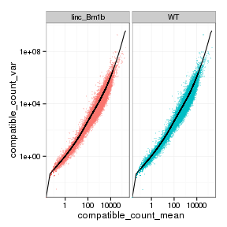

## Cross-replicate variability (fpkmSCVplot)

Differences in CV 2 can result in lower numbers of differentially expressed genes due to a higher degree of variability between replicate fpkm estimates.

Genes:

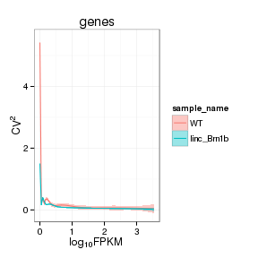

Isoforms:

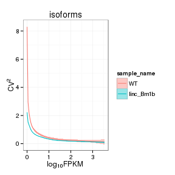

## MvA plot

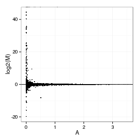

### MvA plot counts

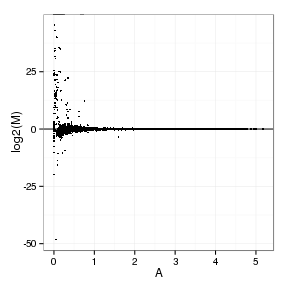

## Scatterplot matrix

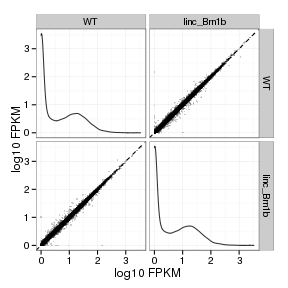

## Distributions

### Boxplots

Boxplot (genes)

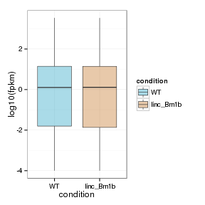

Boxplot (genes, replicates)

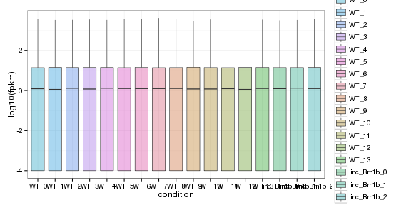

Boxplot (isoforms)

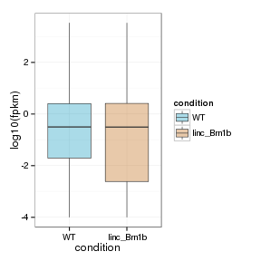

Boxplot (isoforms, replicates)

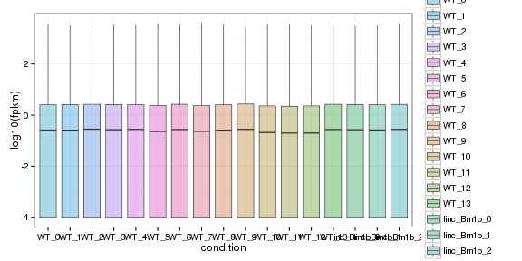

### Density

Density (genes)

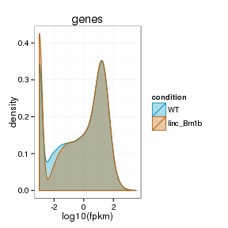

Density (genes, replicates)

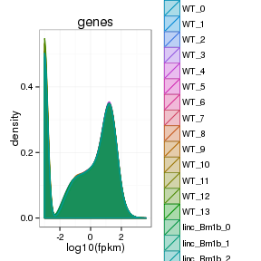

## Clustering

### Replicate Clusters

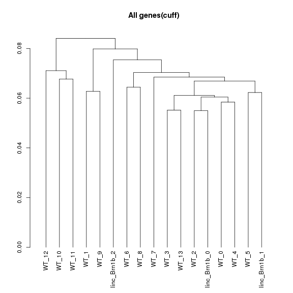

### PCA (genes)

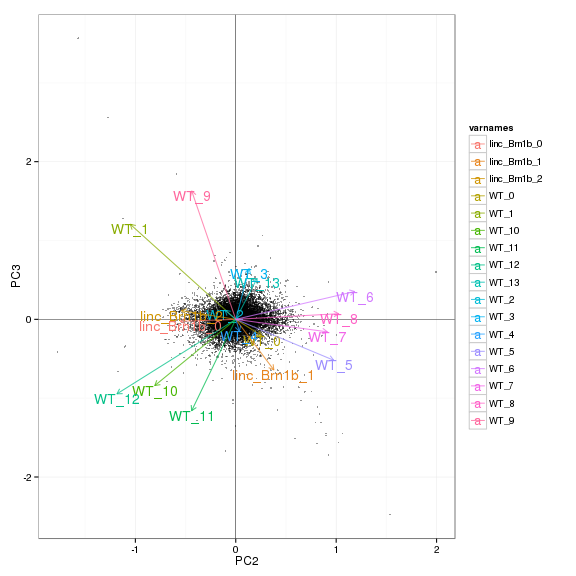

### MDS (genes)

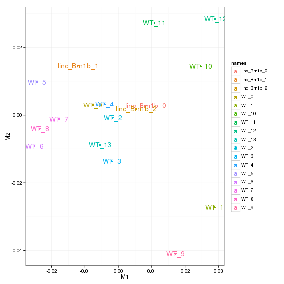

# KO assessment

## Endogenous lncRNA expression

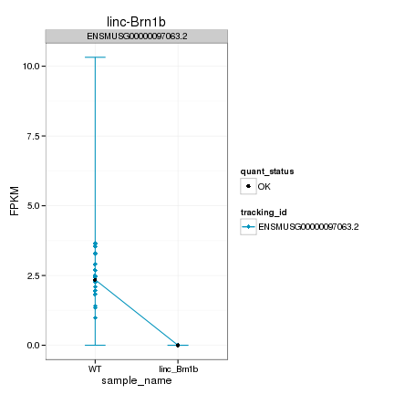

Endogenous expression of linc-Brn1b isoforms:

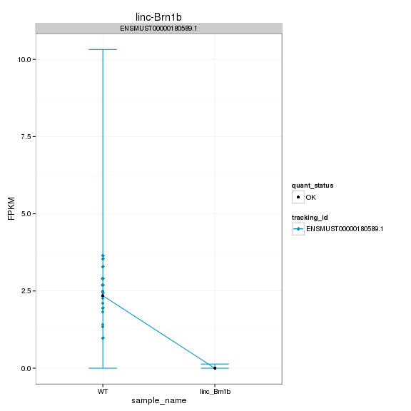

Barplot of gene expression:

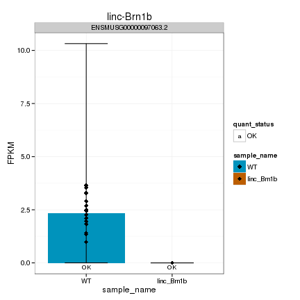

Barplot of isoform expression:

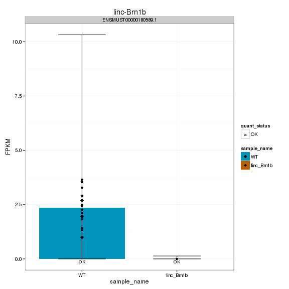

## LacZ expression

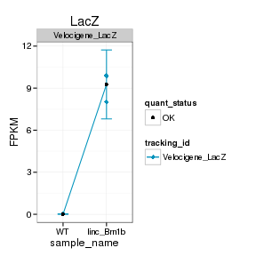

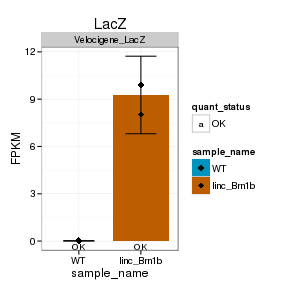

## Digital Genotyping (LacZ vs Endogenous lncRNA and Sex)

Eif2s3y is a y-expressed gene, Xist is an x-expressed gene Expression plot (endogenous linc, lacZ, Y-expressed gene):

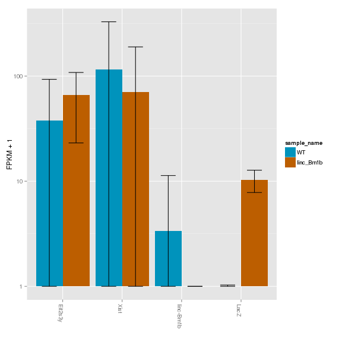

Expression heatmap:

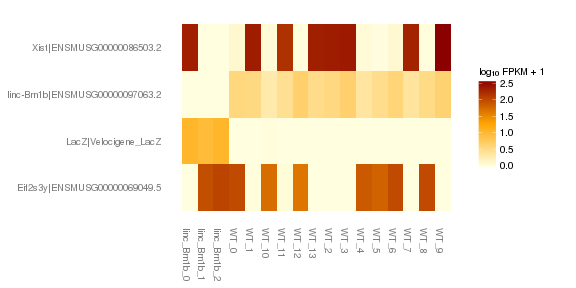

### Track visualization

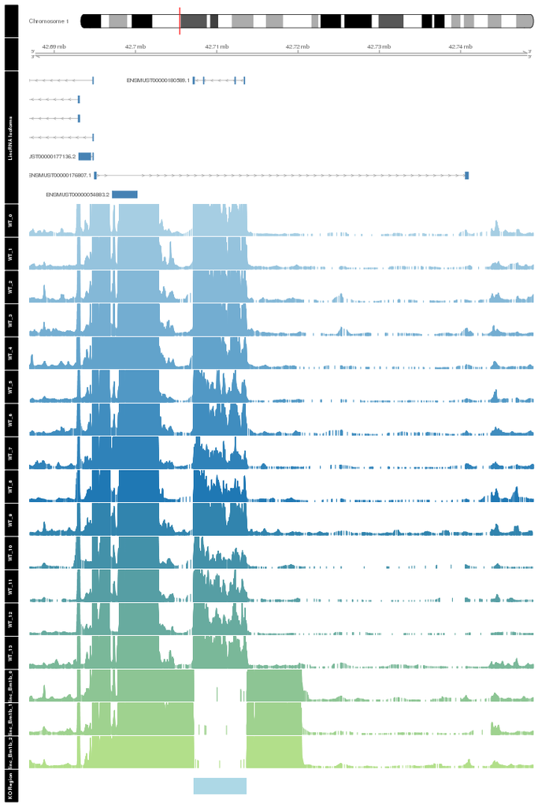

# Differential Analysis

## Differential Genes

There are 130 significantly differentially expressed genes. They are:

|  | geneAnnot$gene_short_name |
| --- | --- |
| 1 | Glra1 |
| 2 | Sez6 |
| 3 | Nfix |
| 4 | Grik3 |
| 5 | Dlgap1 |
| 6 | Cacna1e |
| 7 | Pax2 |
| 8 | Sst |
| 9 | Crabp2 |
| 10 | Ndrg1 |
| 11 | Mef2c |
| 12 | Syngr3 |
| 13 | Syn2 |
| 14 | Prox1 |
| 15 | Ebf3 |
| 16 | Phox2b |
| 17 | Ptgds |
| 18 | Hivep2 |
| 19 | Rxrg |
| 20 | Celsr1 |
| 21 | Lhx1 |
| 22 | Kitl |
| 23 | Gria1 |
| 24 | Fam49a |
| 25 | Foxg1 |
| 26 | Tfap2a |
| 27 | Fezf2 |
| 28 | Skor1 |
| 29 | Sla |
| 30 | Sncg |

[output cut: 100 more lines]

### Matrix of gene significant differences between conditions

(skip for Brainmap wt-v-ko comparisons)

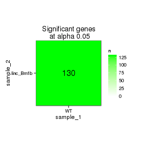

### Significant gene expression differences between conditions

Expression plot (genes):(turned off)

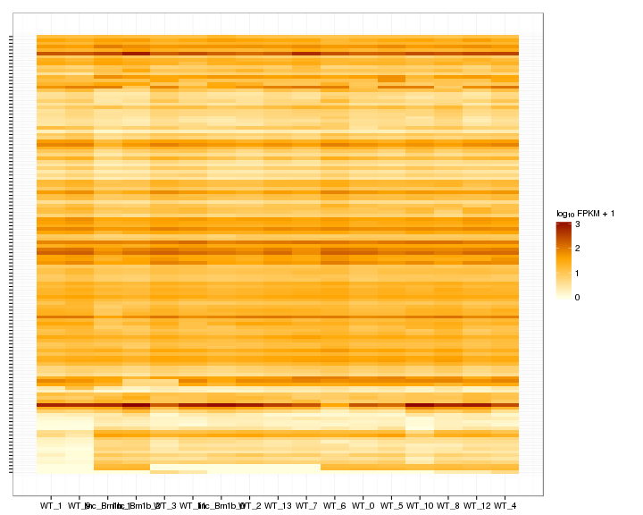

Significant genes with expression >50fpkm (any condition):(turned off)

An individual look at each of the highly expressed significantly differentially regulated genes: (eval=false for first pass)

### Expression-level/significance relationship

Scatter plot of significant genes only:

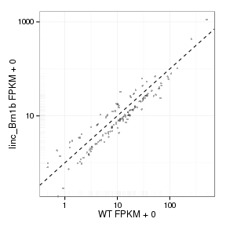

Volcano Plot

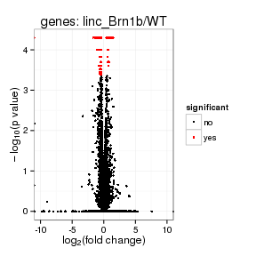

Volcano plot with significant genes only:

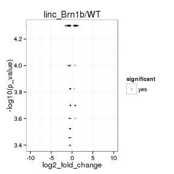

FoldChange Heatmap

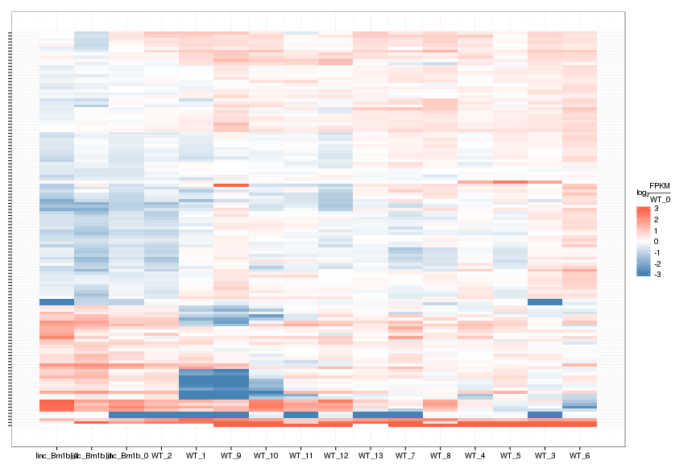